# Homework 11

Kyle Dittmer

4/4/2018

```r
# preliminaries
library(ggplot2)
library(TeachingDemos)
char2seed("Cruel April")

# reading in my crop data
#file.choose()
cornYield = read.csv("/Users/kyledittmer/Desktop/BIO 381/Bio381_2018/BIO381_data.csv")
```

1. Use the code from class as a template and analyze a function of your choosing that is relevant to your own research. Do not change any of the functions in the class code. Instead, copy and rename functions for your own project. Edit those copies, and then modify the lines of code in the main body of your program to call the new functions. If you do this carefully, you will be able to take full advantage of the existing program, but adapt it for your specific use.

```r
##################################################
# function: Yield (lbs/acre)
# predicts crop yield
# input: A = observed corn yield (tons/acre)
        # B = conversion factor for an ear of corn
        # M = moisture
        # R = row length (ft)
        # W = row width (inches)
# output: Y (corn yield)
#-------------------------------------------------
Yield <-function(A=(cornYield)[,4],B=90.439,M=35,R=40,W=240){
  Y <- (((100-M)*A*B)/R)/W
  return(Y)
}
Yield()
```

```
##  [1] 24348.16 27348.66 34315.95 26491.37 23141.83 28276.37 25670.22
##  [8] 23005.28 27367.64 25689.81 28916.88 30690.24 25413.64 24742.51
## [15] 24063.42 24541.05 25493.25 26534.85 27021.05 26187.65 27090.86
## [22] 26951.86 26951.86 27924.27 18602.50 26286.24 23930.54 21088.63
## [29] 29915.01 27472.35 29382.88 28130.01 22997.32 21493.39 30756.37
## [36] 30091.98 22458.45 26847.76 27128.83 26232.35
```

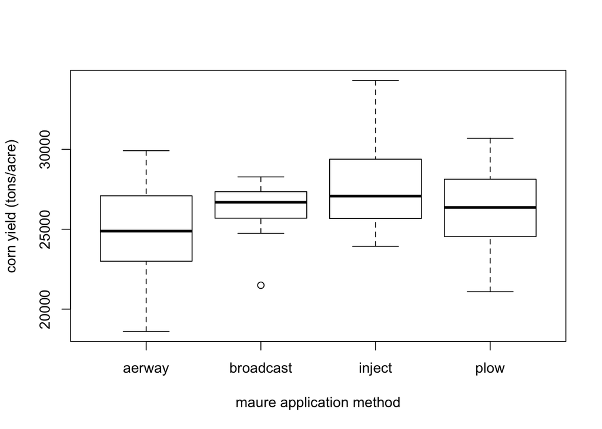

```r
# function to plot above function (simulated)
yieldPlot <- function(A=(cornYield)[,4],B=90.439,M=35,R=40,W=240){
  plot(data=cornYield,x=cornYield[,2],y=Yield(), ylab="corn yield (tons/acre)", xlab="maure application method")
  return()
}
yieldPlot()
```

2. Similarly, use the code from yesterday’s class to design and conduct a randomization test for some of your own data. You will need to modify the functions that read in the data, calculate the metric, and randomize the data. Once those are set up, the program should run correctly calling your new functions. Also, to make your analysis fully repeatable, make sure you set the random number seed at the beginning (use either set.seed() in base R, or char2seed in the TeachingDemos package

```r
cornYield = read.csv("/Users/kyledittmer/Desktop/BIO 381/Bio381_2018/BIO381_data.csv")
########################################################
# FUNCTION: getMetric
# calculate metric for randomization test
# input: data frame
# output: summary table for anova function
#-------------------------------------------------------
getMetric <- function(data=cornYield){
  . <- aov(tons.acre~manure,data=data)
  . <- summary(.)[[1]][["Mean Sq"]][1] # weird code to extract mean squared value from anova
  slope <- .
  return(slope)
}
getMetric()
```

```
## [1] 43929713
```

```r
# another way to find the metric - going to use the sum of squares from summary though
manureMean <- aggregate(cornYield$tons.acre,by=list(cornYield$manure),FUN=mean)
var(manureMean$x)
```

```
## [1] 4392971
```

```r
########################################################
# function: shuffleData
# randomize data for regression analysis
# input: cornYield data frame
# output: cornYield data frame with shuffled values in col. 4
#-------------------------------------------------------
shuffleData <- function(data=cornYield){
  cornYield[,4] <-sample(cornYield[,4])
  return(cornYield)
}
shuffleData()
```

```
##    Year    manure  tillage tons.acre
## 1  2013    aerway       no     43844
## 2  2013 broadcast       no     37556
## 3  2013    inject       no     44241
## 4  2013      plow       no     44303
## 5  2013    aerway vertical     34439
## 6  2013 broadcast vertical     42766
## 7  2013    inject vertical     50227
## 8  2013      plow vertical     44014
## 9  2014    aerway       no     42927
## 10 2014 broadcast       no     43262
## 11 2014    inject       no     41632
## 12 2014      plow       no     42839
## 13 2014    aerway vertical     47223
## 14 2014 broadcast vertical     48853
```

[output cut: 26 more lines]

```r
########################################################
# FUNCTION: getPVal
# calculate p value for obserbed,simulated data
# input: list of observed metric and vector of simulated metric
# output: lower, upper tail
#-------------------------------------------------------
getPVal <- function(data=cornYield){
  cornYield <- list(zObs=runif(1),xSim=runif(1000))
  pLower <- mean(cornYield[[2]] <= cornYield[[1]])
  pUpper <- mean(cornYield[[2]] >= cornYield[[1]])
  return(c(pL=pLower,pU=pUpper))
}
getPVal()
```

```
##   pL   pU
## 0.57 0.43
```

```r
#---------------------------------
# main body of code
nSim <- 1000 # number of simulations
Xsim <- rep(NA,nSim) # will hold simulated slopes

#dF <- readData()
Xobs <- getMetric(cornYield)

for(i in seq_len(nSim)){
  Xsim[i] <- getMetric(shuffleData(cornYield)) }
slopes <- list(Xobs,Xsim)
getPVal(slopes)
```

```
##    pL    pU
## 0.668 0.332
```

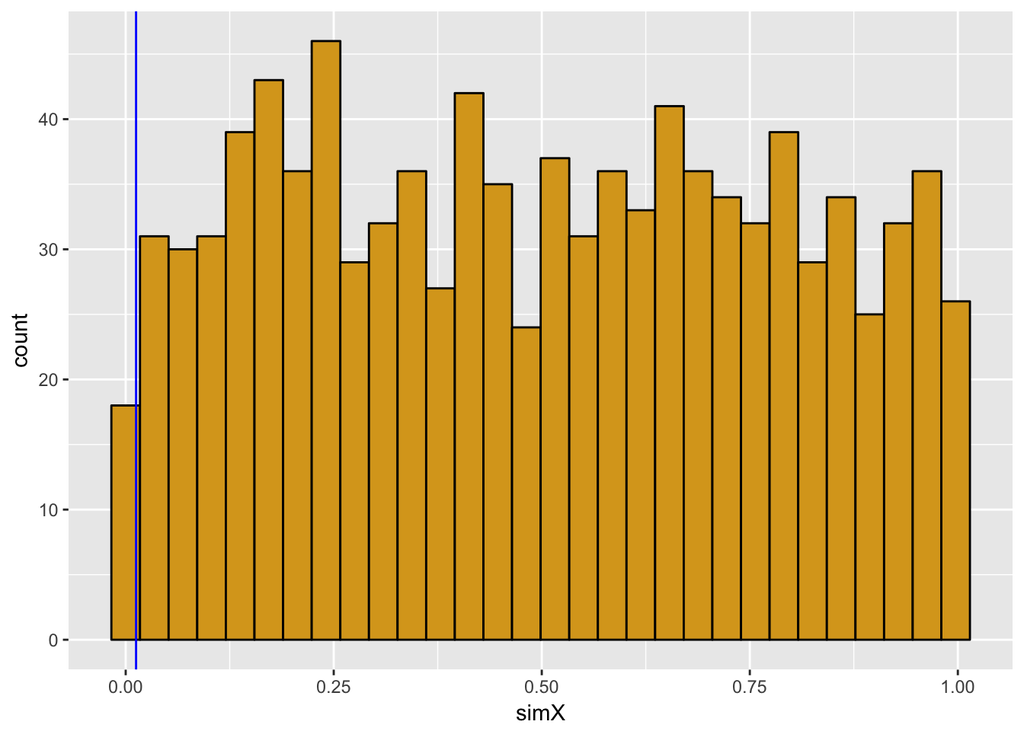

```r
########################################################
# FUNCTION: plotRanTest
# graph
# input: list of observed metric and vector of simulated metric
# output: ggplot graph
#-------------------------------------------------------

plotRanTest <- function(z=NULL) {
  if(is.null(z)) {
  z <- list(zObs=runif(1),xSim=runif(1000)) }
  dF <- data.frame(ID=seq_along(z[[1]]),simX=z[[2]])
  p1 <- ggplot(data=dF,mapping = aes(x=simX))
  p1 + geom_histogram(mapping = aes(fill=I("goldenrod"),color=I("black"))) +
    geom_vline(aes(xintercept=z[[1]],col="blue"))
}
plotRanTest()
```

3. For comparison, calculate in R the standard statistical analysis you would use with these data. How does the p-value compare for the standard test versus the p value you estimated from your randomization test? If the p values seem very different, run the program again with a different starting seed (and/or increase the number of replications in your randomization test). If there are persistent differences in the p value of the standard test versus your randomization, what do you think is responsible for this difference?

```r
# anova for observed crop yield.   p = 0.127
observedANO <- aov(tons.acre~manure,data=cornYield)
summary(observedANO)
```

```
##             Df    Sum Sq  Mean Sq F value Pr(>F)
## manure       3 131789140 43929713   2.027  0.127
## Residuals   36 780074349 21668732
```

```r
# ANOVA for observed and shuffled crop yield. (p-value changes each time I run the code)
shuffledANO <- aov(tons.acre~manure,data = shuffleData())
summary(shuffledANO)
```

```
##             Df    Sum Sq  Mean Sq F value Pr(>F)
## manure       3 126206931 42068977   1.928  0.143
## Residuals   36 785656558 21823793
```